# Bootstrap again

## packages

```r
library(tidyverse)
library(bootstrap)
library(rsample)
library(conflicted)
conflict_prefer("filter", "dplyr")
```

```
[conflicted] Will prefer dplyr::filter over any other package
```

## Is my sampling distribution normal enough?

- Recall the IRS data that we used as a motivation for the sign test:

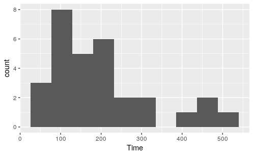

```r
ggplot(irs, aes(x=Time))+geom_histogram(bins=10)
```

- We said that a $t$ procedure for the mean would not be a good idea because the distribution is skewed.

## What *actually* matters

- It’s not the distribution of the *data* that has to be approx normal (for a $t$ procedure).
- What matters is the *sampling distribution of the sample mean*.
- If the sample size is large enough, the sampling distribution will be normal enough even if the data distribution is not.
  - This is why we had to consider the sample size as well as the shape.
- But how do we know whether this is the case or not? We only have *one* sample.

## The (nonparametric) bootstrap

- Typically, our sample will be reasonably representative of the population.
- Idea: pretend the sample *is* the population, and sample from it *with replacement*.
- Calculate test statistic, and repeat many times.
- This gives an idea of how our statistic might vary in repeated samples: that is, its sampling distribution.
- Called the **bootstrap distribution** of the test statistic.
- If the bootstrap distribution is approx normal, infer that the true sampling distribution also approx normal, therefore inference about the mean such as $t$ is good enough.
- If not, we should be more careful.

## Why it works

- We typically estimate population parameters by using the corresponding sample thing: eg. estimate population mean using sample mean.
- This called **plug-in principle**.
- The fraction of sample values less than a value $x$ called the **empirical distribution function** (as a function of $x$).
- By plug-in principle, the empirical distribution function is an estimate of the population CDF.
- In this sense, the sample *is* an estimate of the population, and so sampling from it is an estimate of sampling from the population.

## Bootstrapping the IRS data

- Sampling with replacement is done like this (the default sample size is as long as the original data):

```r
boot=sample(irs$Time, replace=T)
mean(boot)
```

```
[1] 188.3
```

- That’s one bootstrapped mean. We need a whole bunch.
- Use the same idea as for simulating power:

```r
rerun(1000, sample(irs$Time, replace=T)) %>%
  map_dbl(~mean(.)) -> means
```

## Sampling distribution of sample mean

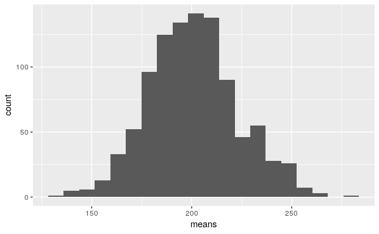

```r
ggplot(tibble(means), aes(x=means))+geom_histogram(bins=20)
```

## Comments

This is not so bad: a long right tail, maybe:

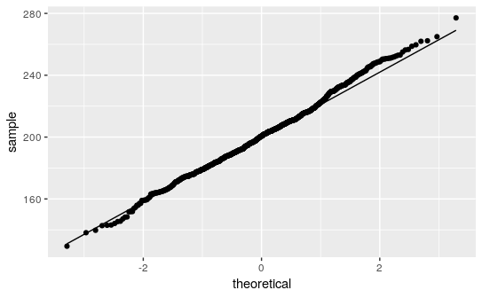

```r
ggplot(tibble(means), aes(sample=means))+
  stat_qq()+stat_qq_line()
```

or not so much.

## Confidence interval from the bootstrap distribution

There are two ways (at least):

- percentile bootstrap interval: take the 2.5 and 97.5 percentiles (to get the middle 95%). This is easy, but not always the best:

```r
(b_p=quantile(means, c(0.025, 0.975)))
```

```
   2.5%   97.5%
159.365 248.405
```

- bootstrap $t$: use the SD of the bootstrapped sampling distribution as the SE of the estimator of the mean and make a $t$ interval:

```r
n=length(irs$Time)
t_star=qt(0.975, n-1)
(b_t=mean(means)+c(-1, 1)*t_star*sd(means))
```

```
[1] 155.3363 246.3731
```

## Comparing

- get ordinary $t$ interval:

```r
my_names=c("LCL", "UCL")
o_t=t.test(irs$Time)$conf.int
```

- Compare the 2 bootstrap intervals with the ordinary $t$-interval:

```r
tibble(limit=my_names, o_t, b_t, b_p)
```

| limit | o_t | b_t | b_p |
| --- | --- | --- | --- |
| LCL | 155.0081 | 155.3363 | 159.365 |
| UCL | 247.4585 | 246.3731 | 248.405 |

## Which to prefer?

- If the intervals agree, then they are all good.
- If they disagree, they are all bad!
- In that case, use BCA interval (over).

## Bias correction and acceleration

- this from “An introduction to the bootstrap”, by Brad Efron and Robert J. Tibshirani.
- there is way of correcting the CI for skewness in the bootstrap distribution, called the BCa method
- complicated (see the Efron and Tibshirani book), but implemented in `bootstrap` package.

## Run this on the IRS data:

```r
bca=bcanon(irs$Time, 1000, mean)
bca$confpoints
```

```
     alpha bca point
[1,] 0.025  164.5667
[2,] 0.050  169.0000
[3,] 0.100  175.5000
[4,] 0.160  180.2667
[5,] 0.840  225.3667
[6,] 0.900  232.0000
[7,] 0.950  241.1667
[8,] 0.975  251.7333
```

## use 2.5% and 97.5% points for CI

```r
bca$confpoints %>% as_tibble() %>%
  filter(alpha %in% c(0.025, 0.975)) %>%
  pull(`bca point`) -> b_bca
b_bca
```

```
[1] 164.5667 251.7333
```

## Comparing

```r
tibble(limit=my_names, o_t, b_t, b_p, b_bca)
```

| limit | o_t | b_t | b_p | b_bca |
| --- | --- | --- | --- | --- |
| LCL | 155.0081 | 155.3363 | 159.365 | 164.5667 |
| UCL | 247.4585 | 246.3731 | 248.405 | 251.7333 |

- The BCA interval says that the mean should be estimated even higher than the bootstrap percentile interval does.
- The BCA interval is the one to trust.

## Bootstrapping the correlation

Recall the soap data:

```r
url="http://www.utsc.utoronto.ca/~butler/c32/soap.txt"
soap=read_delim(url," ")
```

## The data

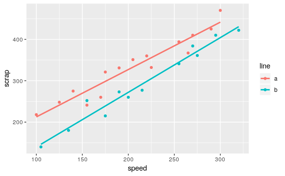

```r
ggplot(soap, aes(x=speed, y=scrap, colour=line))+
  geom_point()+geom_smooth(method="lm", se=F)
```

## Comments

- Line B produces less scrap for any given speed.
- For line B, estimate the correlation between speed and scrap (with a confidence interval.)

## Extract the line B data; standard correlation test

```r
soap %>% filter(line=="b") -> line_b
with(line_b, cor.test(speed, scrap))
```

```
    Pearson's product-moment correlation

data:  speed and scrap
t = 15.829, df = 10, p-value = 2.083e-08
alternative hypothesis: true correlation is not equal to 0
95 percent confidence interval:
 0.9302445 0.9947166
sample estimates:
      cor
0.9806224
```

## Bootstrapping a correlation

- Sample from data with replacement, but have to keep the `speed`-`scrap` *pairs* together
- Sample *rows* at random, then take the variable values that belong to those rows:

```r
rerun(1000, sample(1:nrow(line_b), replace=T)) %>%
  map(~slice(line_b, .)) %>%
  map_dbl(~with(.,cor(speed, scrap))) -> cors
```

## A picture of this

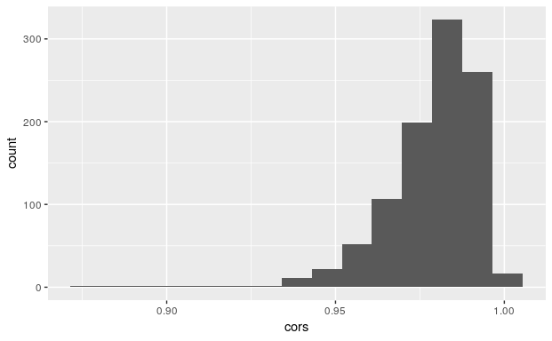

```r
ggplot(tibble(cors), aes(x=cors))+geom_histogram(bins=15)
```

## Comments and next steps

- This is very left-skewed.
- Bootstrap percentile interval is:

```r
(b_p=quantile(cors, c(0.025, 0.975)))
```

```
     2.5%     97.5%
0.9467805 0.9958809
```

- We probably need the BCA interval instead.

## Getting the BCA interval 1/2

- To use `bcanon`, write a function that takes a vector of row numbers and returns the correlation between `speed` and `scrap` for those rows:

```r
theta=function(rows, d) {
  d %>% slice(rows) %>% with(., cor(speed, scrap))
}
theta(1:3, line_b)
```

```
[1] 0.9928971
```

```r
line_b %>% slice(1:3)
```

| case | scrap | speed | line |
| --- | --- | --- | --- |
| 16 | 140 | 105 | b |
| 17 | 277 | 215 | b |
| 18 | 384 | 270 | b |

- That looks about right.

## Getting the BCA interval 2/2

- Inputs to `bcanon` are now:
  - row numbers (1 through 12 in our case: 12 rows in `line_b`)
  - number of bootstrap samples
  - the function we just wrote
  - the data frame:

```r
points=bcanon(1:12, 1000, theta, line_b)$confpoints
points %>% as_tibble() %>%
  filter(alpha %in% c(0.025, 0.975)) %>%
  pull(`bca point`) -> b_bca
b_bca
```

```
[1] 0.9201579 0.9951418
```

## Comparing the results

```r
tibble(limit=my_names, o_c, b_p, b_bca)
```

| limit | o_c | b_p | b_bca |
| --- | --- | --- | --- |
| LCL | 0.9302445 | 0.9467805 | 0.9201579 |
| UCL | 0.9947166 | 0.9958809 | 0.9951418 |

- The bootstrap percentile interval doesn’t go down far enough.
- The BCA interval seems to do a better job than the ordinary `cor.test` interval in capturing the skewness of the distribution.

## A problem

Consider this example: samples of UK and Ontario (Canada) children, and their journey times to school, in minutes:

```r
my_url="http://www.utsc.utoronto.ca/~butler/c32/to-school.csv"
to_school=read_csv(my_url)
to_school
```

| traveltime | location |
| --- | --- |
| 30 | Ontario |
| 10 | Ontario |
| 8 | Ontario |
| 30 | Ontario |
| 5 | Ontario |
| 8 | Ontario |
| 7 | Ontario |
| 15 | Ontario |
| 10 | Ontario |
| 35 | Ontario |

[output cut: 70 more lines]

```r
to_school %>% count(location)
```

| location | n |
| --- | --- |
| Ontario | 40 |
| UK | 40 |

We want to compare the mean journey times in the two different places. This is a two-sample sitation, and if we are not careful with the bootstrap, things will go wrong:

```r
sample(1:nrow(to_school), replace=T) %>% slice(to_school, .) %>% count(location)
```

| location | n |
| --- | --- |
| Ontario | 32 |
| UK | 48 |

Our original samples were 40 from each location, but by randomly resampling rows, we probably *don’t* get 40 from each. We need to draw “stratified resamples” to ensure that we get 40 from each place. This is hard to organize with the build-it-yourself bootstrap. To make things easier, we use the `rsample` package, but then we have to worry about handling the results.

## Automating the bootstrap

Let’s go back to our IRS data for a moment:

```r
irs
```

| Time |
| --- |
| 91 |
| 64 |
| 243 |
| 167 |
| 123 |
| 65 |
| 71 |
| 204 |
| 110 |
| 178 |

[output cut: 20 more lines]

What happens if we use `rsample` to resample from these? Let’s just do a few to start. `rsample` has a function `bootstraps` that does this:

```r
d <- bootstraps(irs, times=1000)
d
```

```
# Bootstrap sampling
```

| splits | id |
| --- | --- |
|  | Bootstrap0001 |
|  | Bootstrap0002 |
|  | Bootstrap0003 |
|  | Bootstrap0004 |
|  | Bootstrap0005 |
|  | Bootstrap0006 |
|  | Bootstrap0007 |
|  | Bootstrap0008 |
|  | Bootstrap0009 |
|  | Bootstrap0010 |

[output cut: 990 more lines]

Each of those things in `splits` is one bootstrap resample. To get at the things in them, we use `analysis`:

```r
d %>% mutate(sample=map(splits, ~analysis(.))) -> dd
dd
```

```
# Bootstrap sampling
```

|  | splits | id | sample |
| --- | --- | --- | --- |
| 1 |  | Bootstrap0001 |  |
| 2 |  | Bootstrap0002 |  |
| 3 |  | Bootstrap0003 |  |
| 4 |  | Bootstrap0004 |  |
| 5 |  | Bootstrap0005 |  |
| 6 |  | Bootstrap0006 |  |
| 7 |  | Bootstrap0007 |  |
| 8 |  | Bootstrap0008 |  |
| 9 |  | Bootstrap0009 |  |
| 10 |  | Bootstrap0010 |  |

[output cut: 990 more lines]

and then `unnest` the actual samples to see them:

```r
dd %>% unnest(sample)
```

| id | Time |
| --- | --- |
| Bootstrap0001 | 474 |
| Bootstrap0001 | 119 |
| Bootstrap0001 | 64 |
| Bootstrap0001 | 188 |
| Bootstrap0001 | 178 |
| Bootstrap0001 | 228 |
| Bootstrap0001 | 102 |
| Bootstrap0001 | 188 |
| Bootstrap0001 | 215 |
| Bootstrap0001 | 264 |

[output cut: 990 more lines]

The values in `Time` are the resampled-with-replacement times to fill in the form.

What we cared about here was the bootstrap distribution of the sample mean, so that for each of the samples in `dd` we need to find the mean `Time` in it:

```r
dd %>% mutate(the_mean=map_dbl(sample, ~mean(.$Time))) -> ddd
ddd
```

```
# Bootstrap sampling
```

|  | splits | id | sample | the_mean |
| --- | --- | --- | --- | --- |
| 1 |  | Bootstrap0001 |  | 226.1000 |
| 2 |  | Bootstrap0002 |  | 242.1667 |
| 3 |  | Bootstrap0003 |  | 213.8333 |
| 4 |  | Bootstrap0004 |  | 245.7667 |
| 5 |  | Bootstrap0005 |  | 222.3000 |
| 6 |  | Bootstrap0006 |  | 170.5000 |
| 7 |  | Bootstrap0007 |  | 197.3667 |
| 8 |  | Bootstrap0008 |  | 168.1667 |
| 9 |  | Bootstrap0009 |  | 212.5333 |
| 10 |  | Bootstrap0010 |  | 179.4333 |

[output cut: 990 more lines]

and for example make a histogram of them, to see how normal this is:

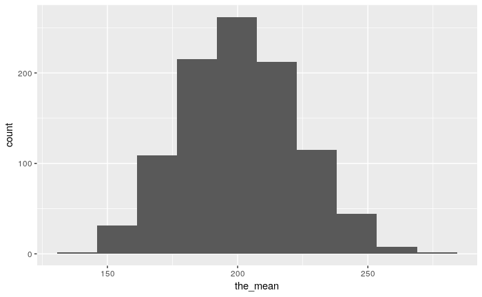

```r
ggplot(ddd, aes(x=the_mean))+geom_histogram(bins=10)
```

This actually looks pretty normal:

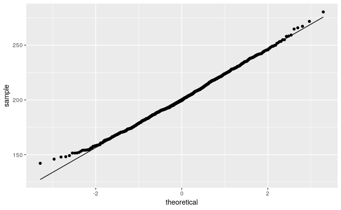

```r
ggplot(ddd, aes(sample=the_mean))+stat_qq()+stat_qq_line()
```

all of which suggests that the $t$-interval for the mean:

```r
with(irs, t.test(Time))
```

```
    One Sample t-test

data:  Time
t = 8.9035, df = 29, p-value = 8.589e-10
alternative hypothesis: true mean is not equal to 0
95 percent confidence interval:
 155.0081 247.4585
sample estimates:
mean of x
 201.2333
```

and some kind of bootstrap interval for the mean, say the percentile-based one:

```r
quantile(ddd$the_mean, c(0.025, 0.975))
```

```
    2.5%    97.5%
158.6317 245.1450
```

won’t be all that far apart.

How do I get the BCa interval from this output? First write a function that gets the mean Time from given rows of a data frame:

```r
theta <- function(rows, d) {
  d %>% slice(rows) %>%
    with(., mean(Time))
}
irs %>% slice(1:3)
```

| Time |
| --- |
| 91 |
| 64 |
| 243 |

```r
theta(1:3, irs)
```

```
[1] 132.6667
```

check. And then feed into `bcanon` these things:

- row numbers of data frame that we want to use (all of them)
- number of … oh, but this uses the original data, or rows thereof

can I do “stratified resampling”? [Yes](https://gist.github.com/ramhiser/8b5ffd0ffbfbf1f49e71bbbd330bf72d)

```r
to_school %>%
  group_by(location) %>%
  sample_frac(replace=T) %>%
  count(location)
```

| location | n |
| --- | --- |
| Ontario | 40 |
| UK | 40 |

that seems to work, but I want to try it on groups of different sizes

```r
groups <- tribble(
  ~group, ~y,
  "A", 1,
  "A", 2,
  "B", 3,
  "B", 4,
  "B", 5
)
groups
```

| group | y |
| --- | --- |
| A | 1 |
| A | 2 |
| B | 3 |
| B | 4 |
| B | 5 |

```r
groups %>%
  group_by(group) %>%
  sample_frac(replace=T)
```

| group | y |
| --- | --- |
| A | 2 |
| A | 2 |
| B | 5 |
| B | 3 |
| B | 4 |

[output not shown]

second step: difference in means between (evidently two) grooups

```r
mean_diff=function(d, var, gp) {
  d %>% group_by({{ gp }}) %>%
    summarize(m=mean({{ var }})) %>% pull(m) -> v
  v[1]-v[2]
}
mean_diff(groups, y, group)
```

```
[1] -2.5
```

bootstrap it

```r
rerun(1000, resample_by_group(groups, y, group)) %>%
  map_dbl(~mean_diff(., y, group)) -> means
```

vis

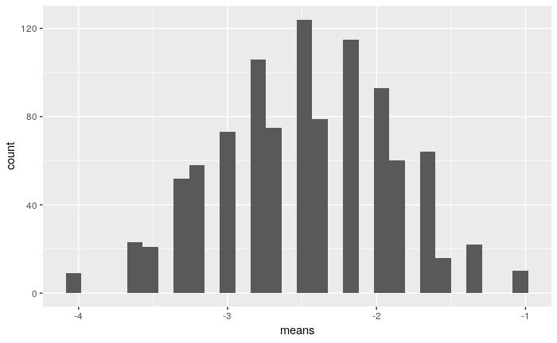

or even

[output not shown]

[output cut: 9 more lines]

this distribution is discrete but more or less normal:

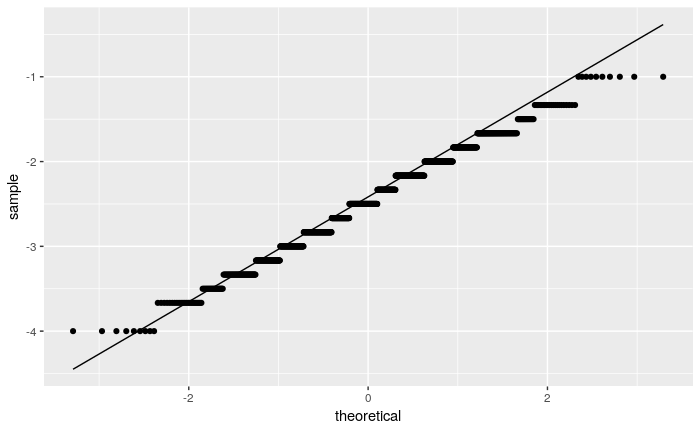

now do it on travel times: this is wrong, because I have to sample the rows properly

```r
rerun(1000, resample_by_group(to_school, traveltime, location)) %>%
  map_dbl(~mean_diff(., traveltime, location)) -> means
```

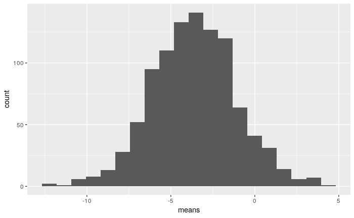

normal quantile plot

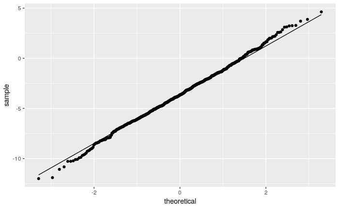

```r
ggplot(tibble(means), aes(sample=means))+stat_qq()+stat_qq_line()
```

ok, but that still doesn’t solve bcanon. (I think, don’t solve that.)